# Week 6 HW R functions

Candice Lei (A18585167)

2026-04-20

#Section 1: Improving analysis code by writing functions

# (A. Can you improve this analysis code?)

Function input: a numeric vector It rescales values to range from 0 to 1 Function output: a rescaled numeric vector

```r
rescale01 <- function(x) {
  if(all(is.na(x))) {
    return(x)
  }
  (x-min(x, na.rm = TRUE)) / (max(x, na.rm = TRUE) - min(x, na.rm = TRUE))
}
df <- data.frame(
a=1:10,
b=seq(200,400,length=10),
c=11:20,
d=NA
)

df[] <- lapply(df, rescale01)
print(df)
```

```
##            a         b         c  d
## 1  0.0000000 0.0000000 0.0000000 NA
## 2  0.1111111 0.1111111 0.1111111 NA
## 3  0.2222222 0.2222222 0.2222222 NA
## 4  0.3333333 0.3333333 0.3333333 NA
## 5  0.4444444 0.4444444 0.4444444 NA
## 6  0.5555556 0.5555556 0.5555556 NA
## 7  0.6666667 0.6666667 0.6666667 NA
## 8  0.7777778 0.7777778 0.7777778 NA
## 9  0.8888889 0.8888889 0.8888889 NA
## 10 1.0000000 1.0000000 1.0000000 NA
```

# (B. Can you improve this analysis code?)

```r
library(bio3d)

plot_protein_bfactor <- function(pdb_id, chain_id = "A") {
  pdb <- read.pdb(pdb_id)
  pdb_chain <- trim.pdb(pdb, chain = chain_id, elety = "CA")
  bfactor <- pdb_chain$atom$b

  plotb3(bfactor, sse = pdb_chain, typ = "l", ylab = "B-factor")

  return(bfactor)
}
```

```
##   Note: Accessing on-line PDB file
```

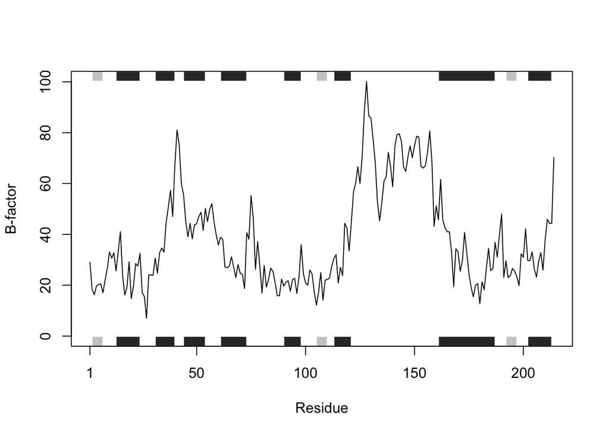

```r
s1 <- plot_protein_bfactor("4AKE") # kinase with drug
```

```
##   Note: Accessing on-line PDB file
##    PDB has ALT records, taking A only, rm.alt=TRUE
```

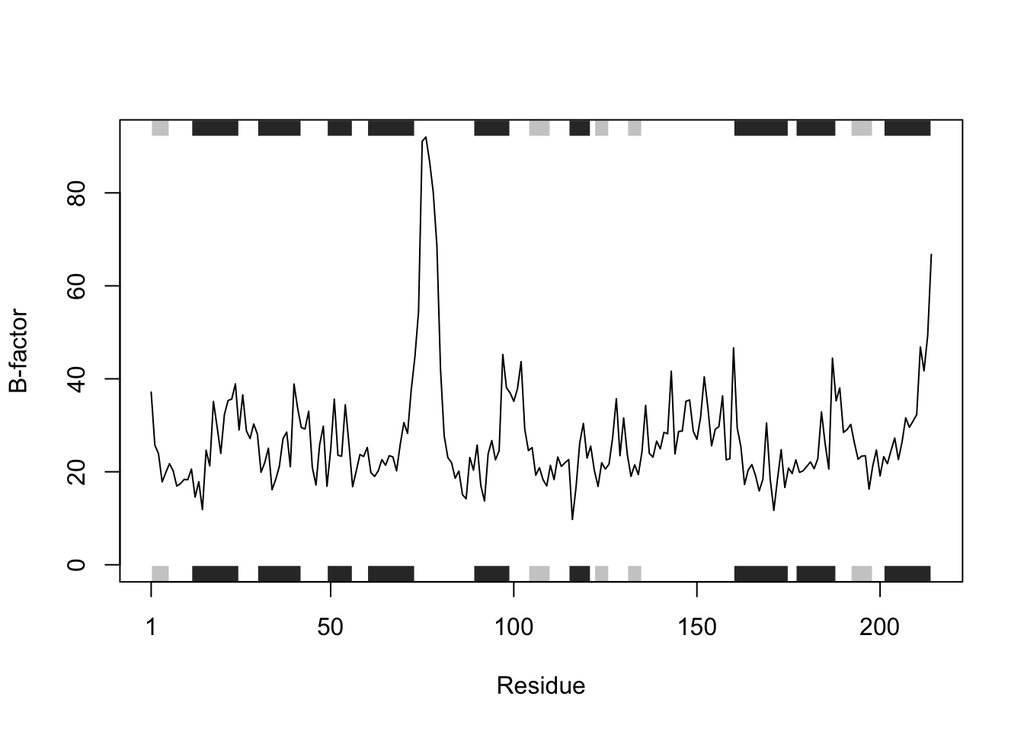

```r
s2 <- plot_protein_bfactor("1AKE") # kinase no drug
```

```
##   Note: Accessing on-line PDB file
```

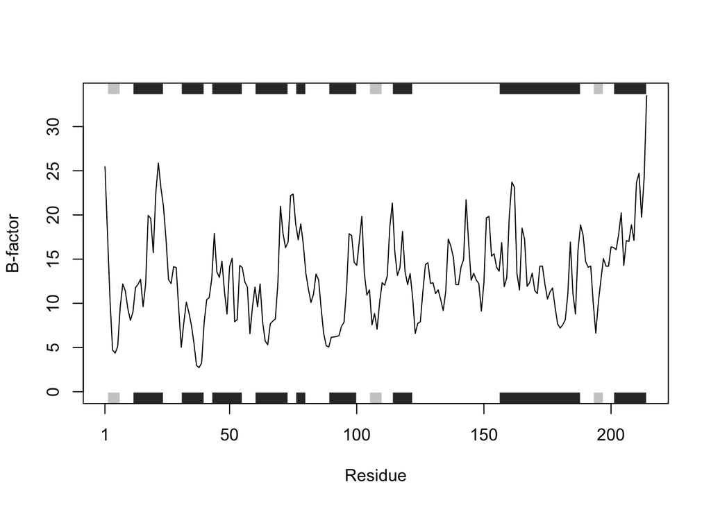

```r
s3 <- plot_protein_bfactor("1E4Y") # kinase with drug
```

Inputs: pdb_id = PDB identifier chain_id = protein chain to analyze

What it does: It reads the PDB structure. It also keeps only the alpha carbons from the chose chain, extracts B-factors and then plots them.

## Q1. What type of object is returned from the **read.pdb()** function?

The function returns a PDB object in r. The PDB objects contains structural information from the protein file.

## Q2. What does the **trim.pdb()** function do?

The function **trim.pdb()** subsets the PDB structure to only keep the selected atoms or residues. For this example, it kept Chain A and atoms of type CA.

## Q3. What input parameter would turn off the marginal black and grey rectangles in the plots and what do they represent in this case?

The sse = FALSE turns off the marginal black and grey rectangles. They represent the secondary structure elements for the protein.

## Q4. What would be a better plot to compare across the different proteins?

A single overlay line plot

## Q5. Which proteins are more similar to each other in their B-factor trends. How could you quantify this?

The two proteins that cluster together in the dendrogram are more similar to each other in their B-factor trends. I can quantify this by using **rbind()** to combine the B-factor vectors, **dist()** to calculate the distances, and **hclust()** clustering.

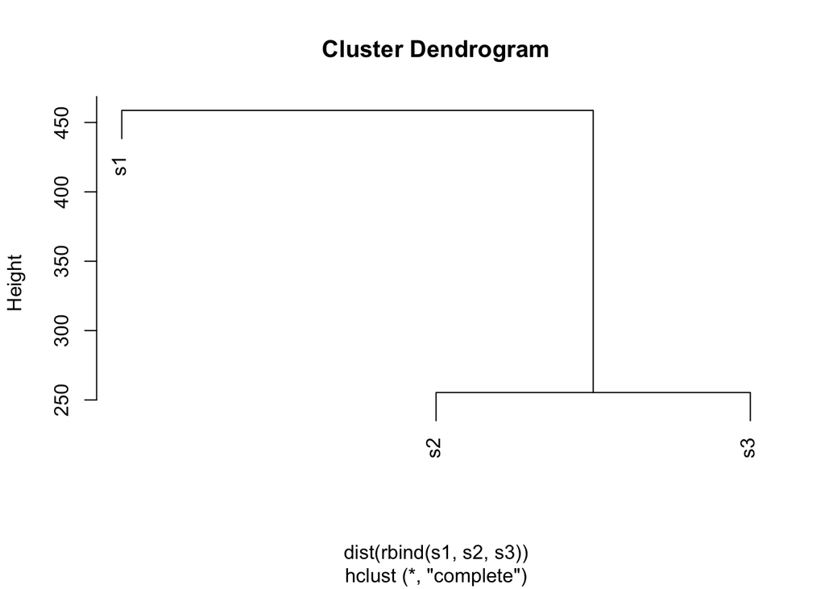

```r
hc <- hclust( dist( rbind(s1, s2, s3) ) )
plot(hc)
```

## Q6. How would you generalize the original code above to work with any set of input protein structures?

```
##   Note: Accessing on-line PDB file
```

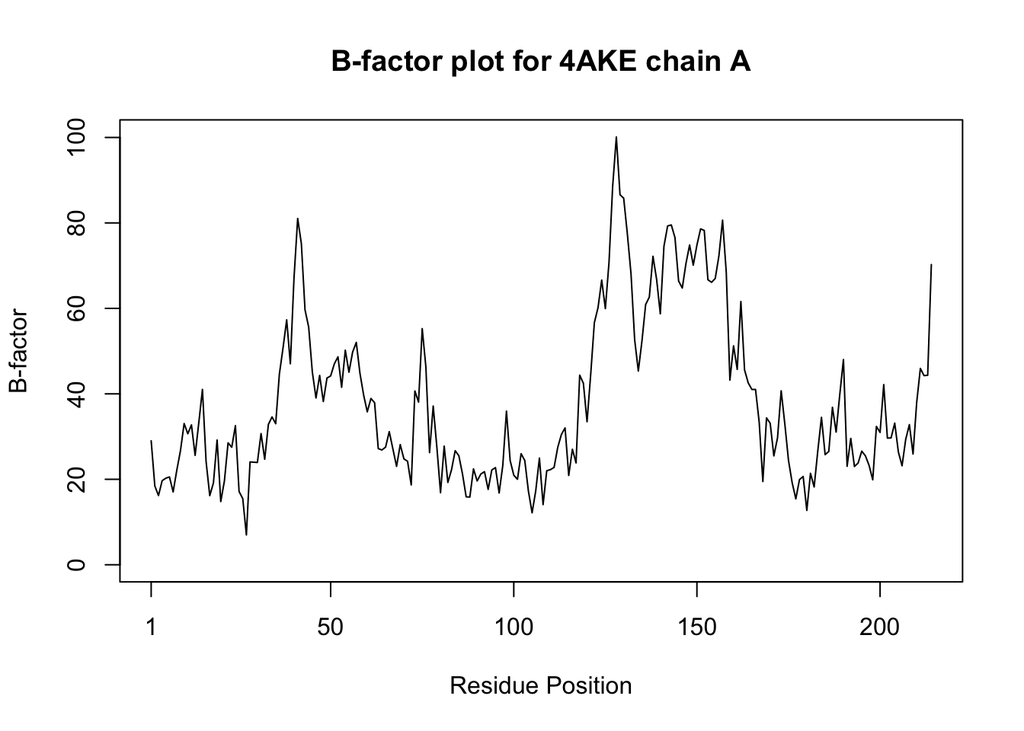

```r
library(bio3d)

# Function inputs:
# pdb_id = 4-character Protein Data Bank ID
# chain_id = protein chain to analyze

# What function does:
# The function reads a PDB structure, trims it to the selected chain and CA atoms, extracts the B-factors, and then plots it.

# How to use:
# Use the **analyze_protein("4AKE")** function
# Function output:
# It returns the B-factor values for selected chain as a numeric vector

analyze_protein <- function(pdb_id, chain_id = "A") {
  #Read the PDB structure
  pdb <- read.pdb(pdb_id)

  #Keep chose chain and CA atoms
  pdb_chain <- trim.pdb(pdb, chain = chain_id, elety = "CA")

  #Extract B-factors
  b_factors <- pdb_chain$atom$b

  #Plot B-factors
  plotb3(b_factors,
         sse = FALSE,
         typ = "l",
         ylab = "B-factor",
         xlab = "Residue Position",
         main = paste("B-factor plot for", pdb_id, "chain", chain_id))

  #Return B-factor vector
  return(b_factors)
}

#Function calls
s1 <- analyze_protein("4AKE")
```

```r
s2<- analyze_protein("1AKE")
```

```
##   Note: Accessing on-line PDB file
```

```
##    PDB has ALT records, taking A only, rm.alt=TRUE
```

[figure not shown]

```r
s3 <- analyze_protein("1E4Y")
```

```
##   Note: Accessing on-line PDB file
```

[figure not shown]